# Aplicações Bootstrap

### O que é Bootstrap?

O Boostrap é uma técnica para fazer inferência Estatística e também conhecida como um método de reamostragem.

Visando tangibilizar esse conteúdo, nas próximas definições considere uma amostra aleatória x, tal que x~N(180,10). Vamos calcular uma estimativa bootstrap para a média de x.

### Bootstrap Não Paramétrico

A amostra bootstrap é obtida através de uma reamostragem aleatória e com reposição dos dados originais.

```r
# n - tamanho da amostra
# B - numero de repeticoes bootstrap
n=20
B=1000

#Geração da amostra original
set.seed(123)
x=rnorm(n,180,10)   #gera n valores da N(180,10) - amostra original

###################################
# Calculando uma amostra Bootstrap
###################################
xboot=sample(x,n,T) #gera uma amostra bootstrap
cat('\nA média calculada para uma reamostra bootstrap é: ',round(mean(xboot),digits=4))
```

```
##
## A média calculada para uma reamostra bootstrap é:  181.3413
```

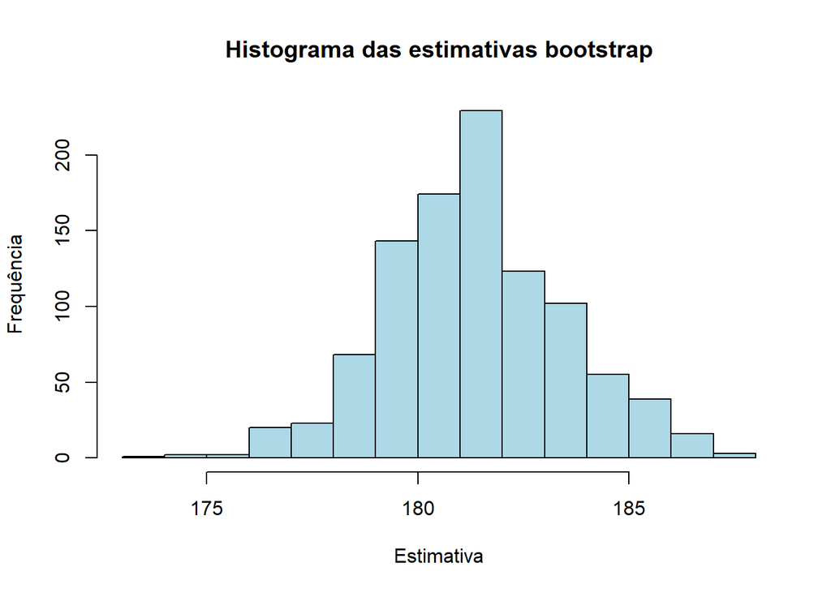

```r
#######################################
# Calculando várias amostras Bootstrap
#######################################
TetaBoot=NULL   #vetor no qual serão armazenados as réplicas bootstrap
for(i in 1:B)
{
    xboot=sample(x,n,T)
    TetaBoot[i]=mean(xboot) #calcula a média para cada amostra bootstrap
}

####################################
# Histograma das amostras bootstrap
####################################
hist(TetaBoot,20,col="lightblue",main="Histograma das estimativas bootstrap",
     ylab='Frequência',xlab='Estimativa')
```

```r
###########################
# Imprimindo os resultados
###########################
cat('\nMédia dos dados: ',round(mean(x),digits=4),
    ' - Erro-padrão da média: ',round(sd(x)/sqrt(n),digits=4),
    '\nMédia das medias: ',round(mean(TetaBoot),digits=4),
    ' - Desvio-padrão das médias ',round(sd(TetaBoot),digits=4),'\n\n')
```

```
##
## Média dos dados:  181.4162  - Erro-padrão da média:  2.1749
## Média das medias:  181.3648  - Desvio-padrão das médias  2.1208
```

### Bootstrap Paramétrico

A amostra bootstrap é obtida através de reamostragem aleatória da distribuição geradora dos dados, com os parâmetros estimados através da amostra original. Este é esperado ser mais eficiente quando as suposições paramétricas forem verdadeiras.

```r
media=mean(x)   #calcula amédia de x
desvio=sd(x)    #calcula o desvio padrão de x

###################################
# Calculando uma amostra Bootstrap
###################################
xboot=rnorm(n,media,desvio)
cat('\nA média calculada para uma reamostra bootstrap é: ',round(mean(xboot),digits=4))
```

```
##
## A média calculada para uma reamostra bootstrap é:  182.6884
```

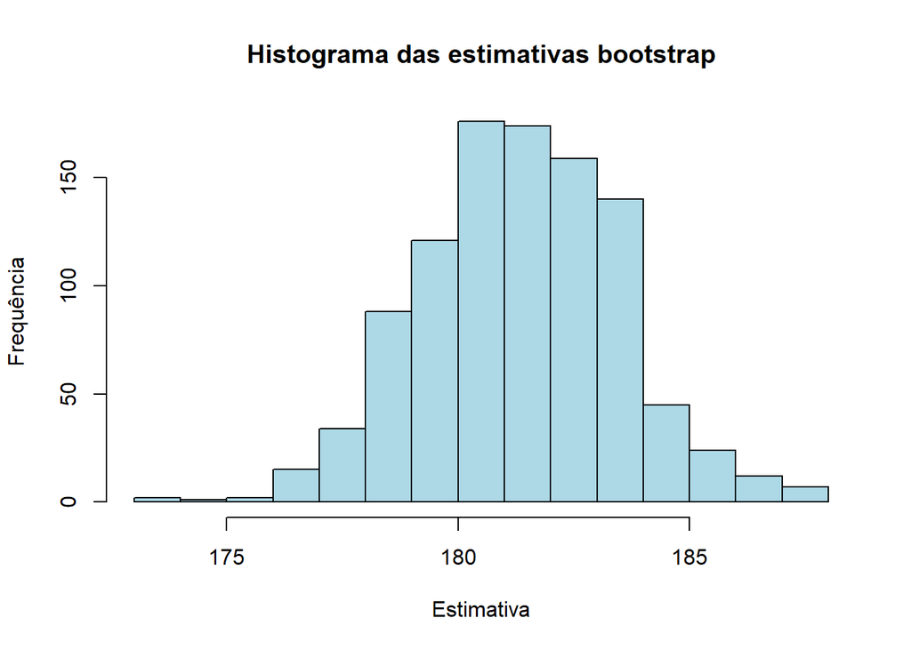

```r
#######################################
# Calculando várias amostras Bootstrap
#######################################
TetaBoot=NULL   #vetor no qual serãoarmazenadas as estimativas bootstrap
for(i in 1:B)
{
    xboot=rnorm(n,media,desvio)
    TetaBoot[i]=mean(xboot)
}

####################################
# Histograma das amostras bootstrap
####################################
hist(TetaBoot,20,col="lightblue",main="Histograma das estimativas bootstrap",
     ylab='Frequência',xlab='Estimativa')
```

```r
################################################
# Imprimindo os resultados
################################################
cat('\nMédia dos dados: ',round(mean(x),digits=4),
    ' - Erro-padrão da média: ',round(sd(x)/sqrt(n),digits=4),
    '\nMédia das medias: ',round(mean(TetaBoot),digits=4),
    ' - Desvio-padrão das médias ',round(sd(TetaBoot),digits=4),'\n\n')
```

```
##
## Média dos dados:  181.4162  - Erro-padrão da média:  2.1749
## Média das medias:  181.3375  - Desvio-padrão das médias  2.1454
```

Observe que a estatística de interesse pode ser qualquer uma. Nesse exemplo, poreríamos trocar a função ‘mean’ por ‘median’, caso fosse de interesse encontrar o percentil de 50% dos dados.

Na literatura existem vários pacotes com implementações bootstrap. Cabe ao leitor ler a documentação para saber mais. Posteriormente, faremos uso de alguns pacotes para demonstração.

### Aplicações

Considere um dataset com as variáveis peso e altura. Façamos uma estimativa bootstrap para o coeficiente de correlação.

Prosseguir com os arquivos: 15-09, 1-10 data

```r
# Exemplo para o coeficiente de correlacao
rm(list=ls(all=TRUE))   # Limpa arquivos na memória do R
require(bootstrap)  # Carrega o pacote bootstrap
```

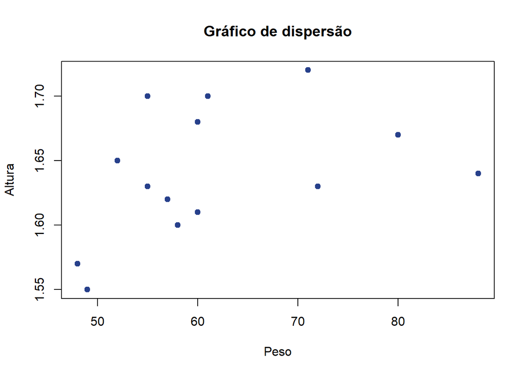

```r
B=1000  # Quantidade de réplicas bootstrap

Peso=c(52,48,60,55,71,80,55,58,49,60,57,55,61,88,72)
Altura=c(1.65,1.57,1.61,1.70,1.72,1.67,1.63,1.60,1.55,1.68,1.62,1.63,1.70,1.64,1.63)

plot(Peso,Altura,pch=19,col='royalblue4',main='Gráfico de dispersão')
```

```r
PA=as.data.frame(cbind(Peso,Altura))
n=dim(PA)[1]    # Quantidade de pares odenados

############################
# Coeficiente de correlação
############################
c=cor(PA$Peso,PA$Altura)    # Calcula do coeficiente de correlação
shapiro.test(PA$Peso)   # Teste de normalidade para a variável Peso
```

```
##
##  Shapiro-Wilk normality test
##
## data:  PA$Peso
## W = 0.88059, p-value = 0.04841
```

```r
shapiro.test(PA$Altura) # Teste de normalidade para a variável Altura
```

```
##
##  Shapiro-Wilk normality test
##
## data:  PA$Altura
## W = 0.97334, p-value = 0.9041
```

```r
cor.test(PA$Peso,PA$Altura) # Teste estatístico para correlação
```

```
##
##  Pearson's product-moment correlation
##
## data:  PA$Peso and PA$Altura
## t = 1.5879, df = 13, p-value = 0.1363
## alternative hypothesis: true correlation is not equal to 0
## 95 percent confidence interval:
##  -0.1376249  0.7586734
## sample estimates:
##       cor
## 0.4030532
```

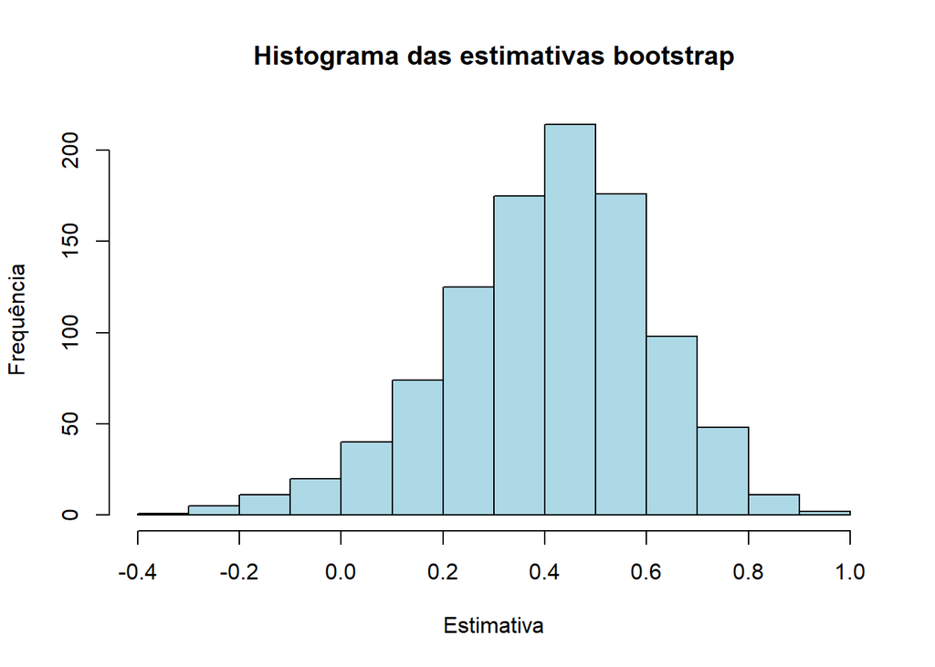

```r
######################
# Inicio do Bootstrap
######################
# Função que calcula a estatística para a qual desejamos a amostra bootstrap
stat=function(ind,x)
{
    x1=x[,1]
    x2=x[,2]
    c=cor(x1[ind],x2[ind])
    return(c)
}

# IMPORTANTE: Nos casos complicados, deve-se tomar alguns cuidados com a estrutura da função stat.
# Note que a função bootstrap não sorteará os pares ordenados diretamente, mas sim o conjunto de índices de 1 até n.
# Tendo esses índices sorteados, a função stat usa os dados originais como argumento auxiliar, tomando a correlação somente dos pares cujos índices foram sorteados.

set.seed(47)    #Definindo uma semente para reprodutibilidade do exemplo
indices=1:n

# Os índices agora representarão os "dados" e PA (dataframe de dados) será um argumento auxiliar
# da função que calcula a estatística que será amostrada (função stat no nosso caso).

correl=bootstrap(indices,B,stat,PA)
EPboot=sd(correl$t) #calcula o erro padrão bootstrap
EPass=(1-c^2)/sqrt(n-3) #calcula o erro padrão assintótico
hist(correl$t,col='lightblue',xlab='Estimativa',ylab='Frequência',main='Histograma das estimativas bootstrap')
```

```r
########################
# Imprime os resultados
########################
cat('\n Coeficiente de correlação: ',round(c,digits=3),
    '\n Coeficiente de correlação bootstrap: ',round(mean(correl$t),digits=3),
    '\n Erro padrão assintotico: ',round(EPass,digits=3),
    '\n Erro padrão bootstrap ',round(EPboot,digits=3),'\n\n')
```

```
##
##  Coeficiente de correlação:  0.403
##  Coeficiente de correlação bootstrap:  0.405
##  Erro padrão assintotico:  0.242
##  Erro padrão bootstrap  0.202
```

### Intervalo de Confiança Percentílico

Considere o conjunto de dados “Surimi”, que é uma proteína de peixe purificada usada como material para fazer imitação de produtos alimentícios de caranguejos e camarões. A força do gel Surimi é um fator critico na produção. Cada porção do material de Surimi cru é amostrado e um gel cozido é preparado. Deste gel, porções são amostradas, testadas no quesito força e gravadas em ma variável x. Calcule um intervalo de confiança de confiança para a força média do gel Surimi.

```r
x=c(41.28,45.16,34.75,40.76,43.61,39.05,41.20,41.02,41.33,40.61,40.49,
    41.77,42.07,44.83,29.12,45.59,41.95,45.78,42.89,40.42,49.31,44.01,
    34.87,38.60,39.63,38.52,38.52,43.95,49.08,50.52,43.85,40.64,45.86,
    41.25,50.35,45.18,39.67,43.89,43.89,42.16)
summary(x)
```

```
##    Min. 1st Qu.  Median    Mean 3rd Qu.    Max.
##   29.12   40.47   41.86   42.19   44.22   50.52
```

```r
shapiro.test(x) #teste de normalidade
```

```
##
##  Shapiro-Wilk normality test
##
## data:  x
## W = 0.94942, p-value = 0.07241
```

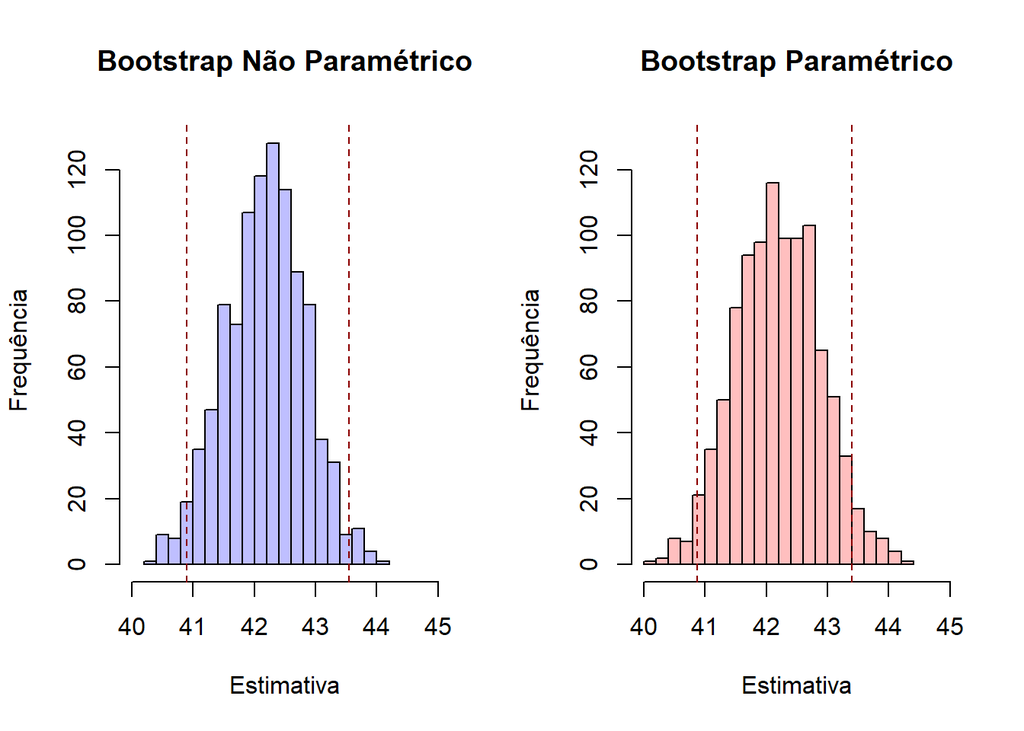

```r
######################################
# Intervalo de confiança percentílico
######################################

#Bootatrap não paramétrico
B=1000 # número de amostras bootstrap
set.seed(1)
require(bootstrap)
mboot=bootstrap(x,B,mean)   # reamostragem bootstrap
medias=mboot$thetastar  # medias bootstrap
ICbootNP=quantile(mboot$t,probs=c(0.025,0.975)) # calcula IC percentílico

#Bootstrap paramétrico
set.seed(2)
n=length(x)
media=mean(x)
desvio=sd(x)
mediaB=NULL
for(i in 1:B)
{
    xboot=rnorm(n,media,desvio)
    mediaB[i]=mean(xboot)
}
ICbootP=quantile(mediaB,probs=c(0.025,0.975))

#Histograma Comparativo
par(mfrow=c(1,2))
hist(medias,20, col=rgb(0,0,1,1/4),main="Bootstrap Não Paramétrico",ylab="Frequência",xlab="Estimativa",xlim=c(40,45),ylim=c(0,130))
abline(v=ICbootP,lty=2,col='darkred')
hist(mediaB,20, col=rgb(1,0,0,1/4),main="Bootstrap Paramétrico",ylab="Frequência",xlab="Estimativa",xlim=c(40,45),ylim=c(0,130))
abline(v=ICbootNP,lty=2,col='darkred')
```

```r
#####################################
# Intervalo de confiança tradicional
#####################################
LI=mean(x)-qt(0.975, n-1)*sd(x)/sqrt(n) # Limite inferior do IC t-student com 95%
LS=mean(x)+qt(0.975, n-1)*sd(x)/sqrt(n) # Limite superior do IC t-student com 95%

# IMPRESSÃO DOS RESULTADOS
cat('IC=[',LI,',',LS,']\n') # IC t-student com 95% de confiança
```

```
## IC=[ 40.85562 , 43.51588 ]
```

```r
cat('ICbootNP=[',ICbootNP[1],',',ICbootNP[2],']\n') # IC percentílico Não Paramétrico com 95% de confiança
```

```
## ICbootNP=[ 40.87568 , 43.39334 ]
```

```r
cat('ICbootP=[',ICbootP[1],',',ICbootP[2],']\n')    # IC percentílico Paramétrico com 95% de confiança
```

```
## ICbootP=[ 40.89235 , 43.55226 ]
```

### Análise de componentes principais

Uma das principais aplicações do PCA é a redução de dimensionalidade. Vejamos um exemplo da estimação da variabilidade dos dados esplicadas pelas duas primeiras componentes a um conjunto de dados de 10 indivíduos submetidos a um determinado tipo de avaliação.

```r
##### LIMPANDO AS VARIÁVEIS #####

rm(list=ls(all=T))

##### DEFININDO A SEMENTE #####

set.seed(1)

##### CRIAÇÃO DO BANCO DE DADOS #####

exatas <- c(9,8,8,9,5,4,7,4,6,3)
humanas <- c(6,0,3,9,5,9,9,10,9,10)
biologicas <- c(5,6,3,8,9,2,9,8,2,7)
fisico <- c(22,28,21,30,21,25,29,29,23,29)
mental <- c(21,18,27,24,22,17,22,30,27,24)
dados <- as.data.frame(cbind(exatas,humanas,biologicas,fisico,mental))
nvar <- ncol(dados);nind <- nrow(dados)

##### MATRIZ DE CORRELAÇÃO #####

correl <- cor(dados)
correl
```

```
##                exatas    humanas  biologicas      fisico      mental
## exatas      1.0000000 -0.5020454 -0.03084040 -0.13763987 -0.13050308
## humanas    -0.5020454  1.0000000  0.11813368  0.39046146  0.34473548
## biologicas -0.0308404  0.1181337  1.00000000  0.49825166  0.09061757
## fisico     -0.1376399  0.3904615  0.49825166  1.00000000  0.01923755
## mental     -0.1305031  0.3447355  0.09061757  0.01923755  1.00000000
```

```r
##### PCA #####
pca=princomp(dados,cor=TRUE)
summary(pca)
```

```
## Importance of components:
##                           Comp.1    Comp.2    Comp.3    Comp.4     Comp.5
## Standard deviation     1.4008393 1.1221399 0.9499633 0.7453871 0.56605569
## Proportion of Variance 0.3924701 0.2518396 0.1804861 0.1111204 0.06408381
## Cumulative Proportion  0.3924701 0.6443097 0.8247958 0.9359162 1.00000000
```

```r
pca$loadings
```

```
##
## Loadings:
##            Comp.1 Comp.2 Comp.3 Comp.4 Comp.5
## exatas      0.428  0.425  0.492 -0.541  0.320
## humanas    -0.581 -0.295        -0.402  0.636
## biologicas -0.371  0.612  0.205  0.575  0.340
## fisico     -0.495  0.480 -0.138 -0.461 -0.542
## mental     -0.311 -0.357  0.829        -0.291
##
##                Comp.1 Comp.2 Comp.3 Comp.4 Comp.5
## SS loadings       1.0    1.0    1.0    1.0    1.0
## Proportion Var    0.2    0.2    0.2    0.2    0.2
## Cumulative Var    0.2    0.4    0.6    0.8    1.0
```

```r
pca$scores
```

```
##           Comp.1     Comp.2      Comp.3      Comp.4      Comp.5
##  [1,]  1.5586531  0.1226543  0.26603242 -0.31147382  0.83623292
##  [2,]  1.6857971  1.8042447 -0.59426517  0.07855134 -1.07355699
##  [3,]  1.8370641 -0.9623352  1.28966370  0.10101694 -0.46312317
##  [4,] -0.7801895  1.3688585  0.73948923 -1.04052505  0.35048799
##  [5,]  0.4200666  0.1089534 -0.07507188  1.86542775  0.62789857
##  [6,]  0.3192885 -1.0814763 -2.20414488 -0.50835430  0.11464705
##  [7,] -1.0265134  1.2451354 -0.04021383 -0.20359107  0.48113589
##  [8,] -2.3201127 -0.4247918  0.86489538  0.34105757 -0.50995556
##  [9,]  0.2062378 -1.8750295  0.48770738 -0.61495186 -0.02385591
## [10,] -1.9002914 -0.3062136 -0.73409234  0.29284251 -0.33991080
```

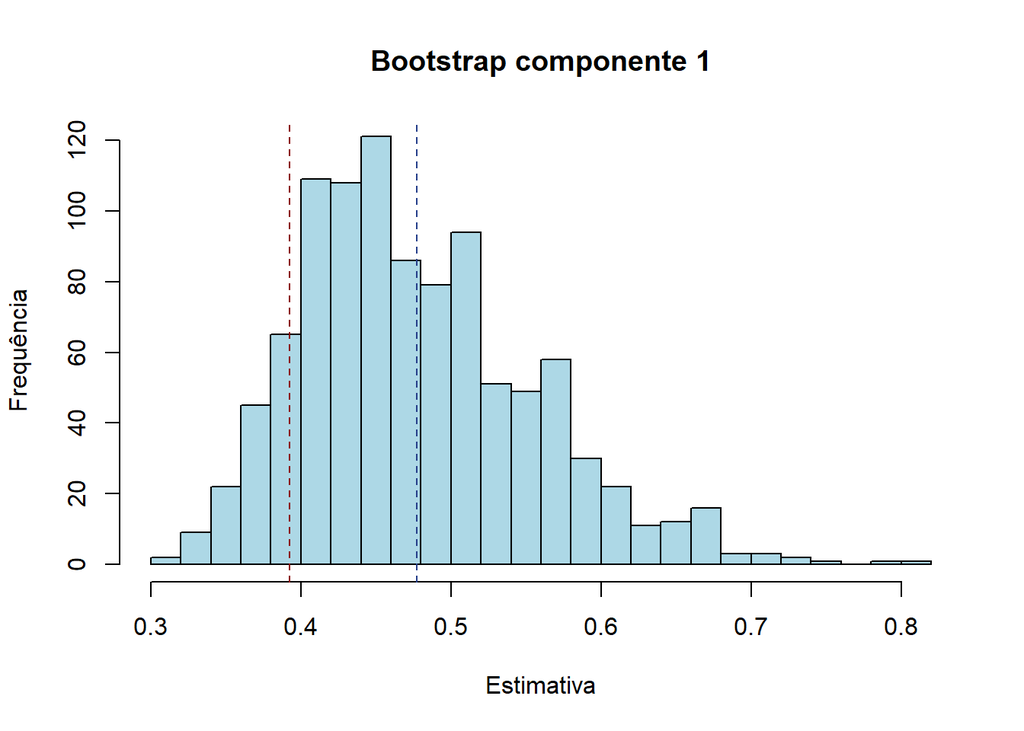

```
##       valorcor valorbootcor
## [1,] 0.3924701    0.4773957
```

```r
##### REALIZAÇÃO DO BOOTSTRAP #####

require(bootstrap)
B <- 1000
analise=dados

#### COMPONENTE 1 ####

PCAboot=function(componente)
{
    thetacor <- function(indice)
    {
        vals <- eigen(cor(analise[indice,]), symmetric=TRUE, only.values=TRUE)$values
        vals[componente] / sum(vals)
    }
    scorbootcor <- bootstrap(1:nind, B, thetacor)
    sd(scorbootcor$thetastar)
    hist(scorbootcor$thetastar,20,col='lightblue',main=paste('Bootstrap componente',componente),ylab='Frequência',xlab='Estimativa')
    abline(v=thetacor(1:nind), col="darkred",lty=2)
    abline(v=mean(scorbootcor$thetastar), col="royalblue4",lty=2)
    valorcor <- as.numeric(pca$sdev[componente]^2/sum(pca$sdev^2))
    valorbootcor <- mean(scorbootcor$thetastar)
    compcor <- cbind(valorcor,valorbootcor)
    print(compcor)
}

PCAboot(1)
```

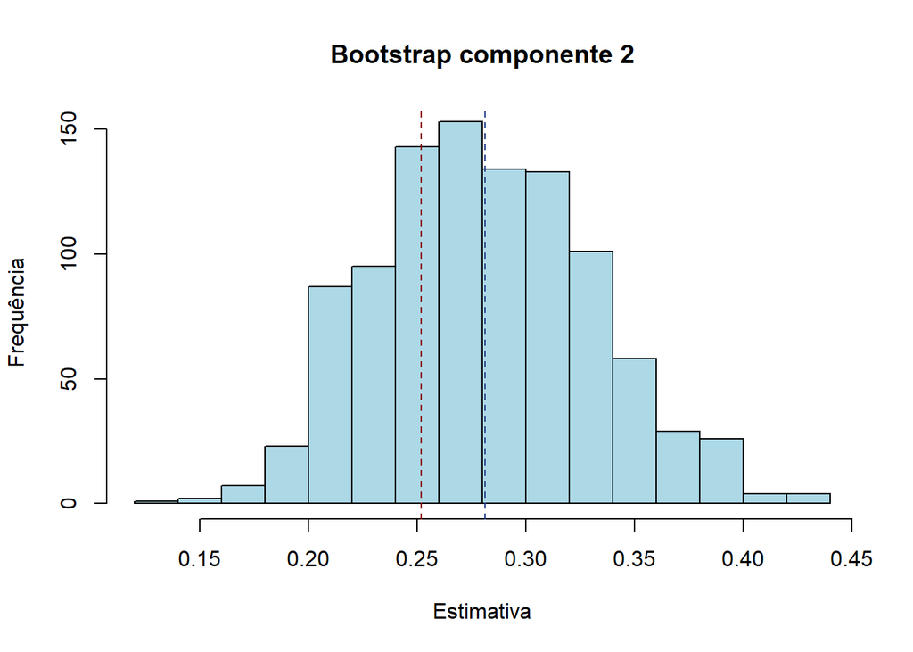

```
##       valorcor valorbootcor
## [1,] 0.2518396    0.2812859
```

```r
PCAboot(2)
```

Note que o percentual da variabilidade dos dados esplicado pelas duas primeiras componentes passou de 64% para 75%. A reamostragem dos dados dimunuiu as incertezas com relação a amostra e atribui mais peso a um número menor de componentes.